# BikeSharingAnalysis

### Estimate the phis for the (1-B^7) differenced data.

```r
est.7=est.ar.wge(b7,p=8)
```

```
##
##
## Coefficients of AR polynomial:
## 0.4042 0.0181 0.0229 0.0423 -0.0059 0.0310 -0.5066 0.2150
##
##                            AR Factor Table
## Factor                 Roots                Abs Recip    System Freq
## 1+0.9199B             -1.0871               0.9199       0.5000
## 1+1.1229B+0.8232B^2   -0.6820+-0.8658i      0.9073       0.3562
## 1-0.3926B+0.8215B^2    0.2389+-1.0771i      0.9064       0.2153
## 1-1.6153B+0.7871B^2    1.0261+-0.4665i      0.8872       0.0679
## 1-0.4392B              2.2771               0.4392       0.0000
##
##
```

### find a P and q for the (1-B^7) differeenced data

Here we will choose an AR(8) still because of the AIC and BIC balance and Box and Jenkins method. And because AR(8) is a simple model.

```
## ---------WORKING... PLEASE WAIT...
##
##
## Five Smallest Values of  aic
##     p    q        aic
##     8    0   15.29743
##     7    0   15.34413
##     6    0   15.55890
##     5    0   15.57382
##     2    0   15.57652
```

```
## ---------WORKING... PLEASE WAIT...
##
##
## Five Smallest Values of  bic
##     p    q        bic
##     8    0   15.31589
##     9    0   15.31764
##    10    0   15.32037
##    11    0   15.32227
##    12    0   15.32480
```

Box and jenkins method for identifiyin AR(P)

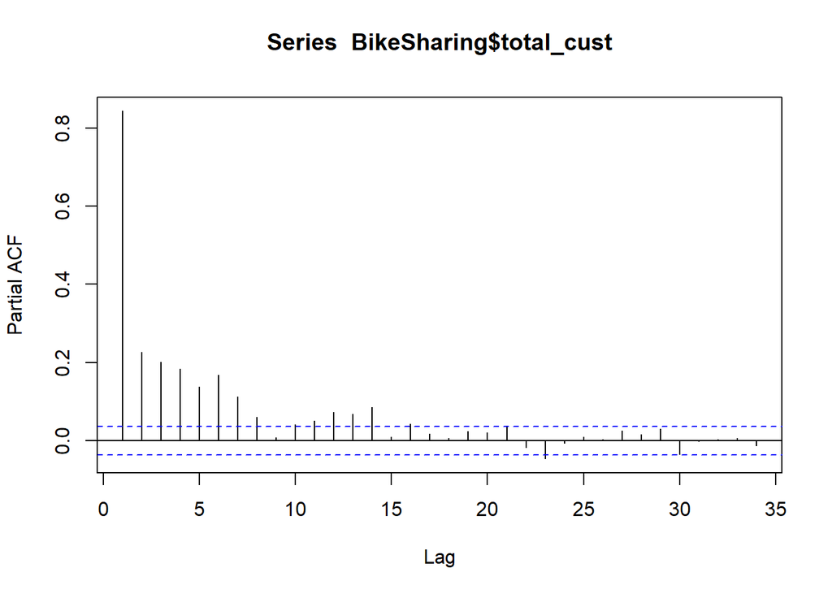

```r
pacf(BikeSharing$total_cust) # suggest an AR(8) model
```

### we will now estimate the phis using burg method on the difference (1-B^7) Bikeshare data.

AIC and BIC Selects an AR(8), and the final model is: phi_subs8(B)(1-B^7)X_t = at, Where phisubs8(B) = 1-0.4043 - 0.0180B^2 - 0.0225B^3- 0.0428B^4 + 0.0060B^5 - 0.0304B^6 + 0.5069B^7 - 0.2151B^8 and Sigmahat_a^2 = 4374309

```r
est.7=est.ar.wge(b7,p=8, method = 'burg')
```

```
##
##
## Coefficients of AR polynomial:
## 0.4043 0.0180 0.0225 0.0429 -0.0060 0.0304 -0.5069 0.2151
##
##                            AR Factor Table
## Factor                 Roots                Abs Recip    System Freq
## 1+0.9200B             -1.0870               0.9200       0.5000
## 1+1.1229B+0.8230B^2   -0.6822+-0.8658i      0.9072       0.3562
## 1-0.3925B+0.8220B^2    0.2388+-1.0768i      0.9066       0.2153
## 1-1.6157B+0.7876B^2    1.0257+-0.4664i      0.8875       0.0679
## 1-0.4389B              2.2783               0.4389       0.0000
##
##
```